# book_classification

```python
import nltk
import re
import random
from nltk import ngrams
import pandas as pd
import seaborn as sns
from nltk.probability import FreqDist
#for model-building
from sklearn.model_selection import train_test_split
from sklearn.model_selection import train_test_split
from sklearn.metrics import make_scorer
from sklearn.tree import DecisionTreeClassifier
from sklearn.svm import SVC
from sklearn.neighbors import KNeighborsClassifier
from sklearn.metrics import classification_report, f1_score, accuracy_score, confusion_matrix
from sklearn.model_selection import GridSearchCV
from sklearn.metrics import classification_report,confusion_matrix
from sklearn.metrics import f1_score, precision_score, recall_score
from sklearn.model_selection import KFold
from sklearn.model_selection import cross_val_score
from collections import defaultdict
import matplotlib.pyplot as plt
import warnings
warnings.filterwarnings('ignore')
nltk.download('gutenberg')
nltk.download('punkt')
```

```
True
```

```python
glutenberg_books = nltk.corpus.gutenberg.fileids()
```

```python
print("These are the books from gutenberg project: ")
for book in glutenberg_books:
    print(book)
```

```
These are the books from gutenberg project:
austen-emma.txt
austen-persuasion.txt
austen-sense.txt
bible-kjv.txt
blake-poems.txt
bryant-stories.txt
burgess-busterbrown.txt
carroll-alice.txt
chesterton-ball.txt
chesterton-brown.txt
chesterton-thursday.txt
edgeworth-parents.txt
melville-moby_dick.txt
milton-paradise.txt
shakespeare-caesar.txt
shakespeare-hamlet.txt
shakespeare-macbeth.txt
whitman-leaves.txt
```

```python
str_input = "how many books do you want between 1 and " + str(len(glutenberg_books)) + ": "
while True:
    try:
        n=int(input(str_input))
        if n not in [i+1 for i in range(len(glutenberg_books))]:
            raise ValueError()
        else:
            break
    except ValueError:
        print("Oops!  That was no valid number.  Try again between 1 and", len(glutenberg_books))
```

```
how many books do you want between 1 and 18: 5
```

```python
print("please select which book you want by the number")
for index, val in enumerate(glutenberg_books):
    print("for ",val, "select: ", index+1)

book_list = []
for i in range(n):
    while True:
        try:
            book_number = int(input())
            if book_number in book_list:
                raise ValueError()
            if book_number not in [i+1 for i in range(len(glutenberg_books))]:
                raise ValueError()
            book_list.append(book_number)
            break
        except ValueError:
            print("eithe this book you have entered have been already or you have given a wrong input, please provide input between 1 and", len(glutenberg_books))
```

```
please select which book you want by the number
for  austen-emma.txt select:  1
for  austen-persuasion.txt select:  2
for  austen-sense.txt select:  3
for  bible-kjv.txt select:  4
for  blake-poems.txt select:  5
for  bryant-stories.txt select:  6
for  burgess-busterbrown.txt select:  7
for  carroll-alice.txt select:  8
for  chesterton-ball.txt select:  9
for  chesterton-brown.txt select:  10
for  chesterton-thursday.txt select:  11
for  edgeworth-parents.txt select:  12
for  melville-moby_dick.txt select:  13
for  milton-paradise.txt select:  14
for  shakespeare-caesar.txt select:  15
for  shakespeare-hamlet.txt select:  16
for  shakespeare-macbeth.txt select:  17
for  whitman-leaves.txt select:  18
6
12
13
9
14
```

```python
print("These are the books that you have ordered for: ")
for book in book_list:
    print(glutenberg_books[book-1])
```

```
These are the books that you have ordered for:
bryant-stories.txt
edgeworth-parents.txt
melville-moby_dick.txt
chesterton-ball.txt
milton-paradise.txt
```

```python
def getcorpus_and_authors_for_book_list(books):
    book_corpus = []
    authors = []
    for book in books:
        text = nltk.corpus.gutenberg.raw(glutenberg_books[book-1])
        # tokenize words
        # text_words = nltk.word_tokenize(text)
        author_name = glutenberg_books[book-1].split('-')[0]
        book_corpus.append(text)
        authors.append(author_name)

    return authors, book_corpus
```

```python
authors, book_corpus = getcorpus_and_authors_for_book_list(book_list)

d = {'authors_name' : authors, 'book_corpus' : book_corpus}

df_raw_corpus = pd.DataFrame(d)
```

```python
df_raw_corpus.to_csv('gutenberg_books.txt', encoding='utf-8', index=False, sep=',')
```

```python
df_raw_corpus.head()
```

|  | authors_name | book_corpus |
| --- | --- | --- |
| 0 | bryant | [Stories to Tell to Children by Sara Cone Brya... |
| 1 | edgeworth | [The Parent's Assistant, by Maria Edgeworth]\r... |
| 2 | melville | [Moby Dick by Herman Melville 1851]\r\n\r\n\r\... |
| 3 | chesterton | [The Ball and The Cross by G.K. Chesterton 190... |
| 4 | milton | [Paradise Lost by John Milton 1667] \n \n \nBo... |

# # Start from here, The previous code is for extracting the text from the book collections

```python
df_raw_corpus_test = pd.read_csv('gutenberg_books.txt') # reading the books
```

```python
df_raw_corpus_test.head()
```

|  | authors_name | book_corpus |
| --- | --- | --- |
| 0 | bryant | [Stories to Tell to Children by Sara Cone Brya... |
| 1 | edgeworth | [The Parent's Assistant, by Maria Edgeworth]\r... |
| 2 | melville | [Moby Dick by Herman Melville 1851]\r\n\r\n\r\... |
| 3 | chesterton | [The Ball and The Cross by G.K. Chesterton 190... |
| 4 | milton | [Paradise Lost by John Milton 1667] \n \n \nBo... |

Now we will clean the data

```python
nltk.download('stopwords')
from nltk.corpus import stopwords
stop_words=set(stopwords.words("english"))
print(stop_words)
```

```
{'ain', 'll', 'were', 'itself', "you'll", "you've", 'you', 'o', "mightn't", 'shan', 'doesn', 'shouldn', "you'd", "wasn't", 'being', 'because', "wouldn't", 'an', 'couldn', 'nor', 'when', 'doing', 'hadn', 'have', 'only', 'no', 're', 'through', 'does', 'then', 'why', 'himself', 'further', 'whom', 'in',…
```

```python
##Clean the data

#removing all the puntuations
def remove_punctuations(text):
    text_words = nltk.word_tokenize(text)
    file = [w.lower() for w in text_words if w.isalpha()] # removing all symbols
    cleaned_text = " ".join(file)

    return cleaned_text


#remove stop words
def remove_stop_words(text):
    text_words = nltk.word_tokenize(text)
    file = [w.lower() for w in text_words if w not in stop_words] # removing all symbols
    text_without_stop_word = " ".join(file)

    return text_without_stop_word
# print("Tokenized Word:",tokenized_word)
# print("Filterd Sentence:",filtered_sents)
```

```python
df_raw_corpus_test['clean_corpus'] = df_raw_corpus_test['book_corpus'].apply(remove_punctuations) #removing punctuations from the text
```

```python
df_raw_corpus_test['clean_corpus_without_stopwords'] = df_raw_corpus_test['clean_corpus'].apply(remove_stop_words) #removing stop words from the clean text and storing it in a dataframe
```

```python
df_raw_corpus_test.head()
```

|  | authors_name | book_corpus | clean_corpus | clean_corpus_without_stopwords |
| --- | --- | --- | --- | --- |
| 0 | bryant | [Stories to Tell to Children by Sara Cone Brya... | stories to tell to children by sara cone bryan... | stories tell children sara cone bryant two lit... |
| 1 | edgeworth | [The Parent's Assistant, by Maria Edgeworth]\r... | the parent assistant by maria edgeworth the or... | parent assistant maria edgeworth orphans near ... |
| 2 | melville | [Moby Dick by Herman Melville 1851]\r\n\r\n\r\... | moby dick by herman melville etymology supplie... | moby dick herman melville etymology supplied l... |
| 3 | chesterton | [The Ball and The Cross by G.K. Chesterton 190... | the ball and the cross by chesterton i a discu... | ball cross chesterton discussion somewhat air ... |
| 4 | milton | [Paradise Lost by John Milton 1667] \n \n \nBo... | paradise lost by john milton book i of man fir... | paradise lost john milton book man first disob... |

Now we have a column of the clean corpus without the stop words, which can be used for exploratory data analysis and eda. But before that we should see the number of the words that exist in each books for each authors, as we will create 200 partitions for the data.

```python
for row in range(len(df_raw_corpus_test['authors_name'])):
    print(len(df_raw_corpus_test['clean_corpus_without_stopwords'][row].split(" ")))
```

```
21206
75717
105071
38808
44771
```

Now we will partition in three ways, one is taking random words with size of 100 and create 200 paritions. Another is taking bigrams of size 100 and another is taking 100 grams.

```python
def parition_ngrams(df, t_size = 100, partition_n = 200, n = 100): # n =50 partition_n = 50
    df_raw_corpus_test = df
    d = {}
    partitions = []
    authors = []


    for row in range(len(df_raw_corpus_test['authors_name'])):

        file = nltk.Text(nltk.word_tokenize(df_raw_corpus_test['clean_corpus_without_stopwords'][row])) # selecting the book

        # file = [w.lower() for w in file if w.isalpha()] # removing all symbols

        n_grams =  list(ngrams(file, n))

        for i in range(partition_n):
            sample_list = []
            for i in range(t_size):
                index = random.randrange(0, len(n_grams))
                element = n_grams.pop(index)
                sample_list.append(element)
            partition = " ".join(sample_list[99])
            partitions.append(partition)
            authors.append(df_raw_corpus_test['authors_name'][row])


    d = {'authors_name' : authors, 'context' : partitions}

    new_df = pd.DataFrame(d)

    return new_df

# new_df.to_csv('gutenberg_books_partitioned.txt', encoding='utf-8', index=False, sep=',')
```

```python
def parition_with_random_words(df, t_size = 100, partition_n = 200):
    partitions = []
    authors = []
    df_raw_corpus_test = df

    for row in range(len(df_raw_corpus_test['authors_name'])):


        file = nltk.Text(nltk.word_tokenize(df_raw_corpus_test['clean_corpus_without_stopwords'][row]))
        file = list(file)
        words = file

        for i in range(partition_n):
            a = []
            for j in range(t_size):
                index = random.randrange(0, len(words))
                a.append(words.pop(index))
            partition = " ".join(a)
            partitions.append(partition)
            authors.append(df_raw_corpus_test['authors_name'][row])

    d = {'authors_name' : authors, 'context' : partitions}

    new_df_2 = pd.DataFrame(d)

    return new_df_2
```

```python
#creating a dataframe with 100 grams and 200 paritions for those 5 authors
df_with_100_gram = parition_ngrams(df_raw_corpus_test, t_size = 100, partition_n = 200, n = 100)
df_with_2_gram = parition_ngrams(df_raw_corpus_test, t_size = 100, partition_n = 200, n = 2)
df_with_random_picks = parition_with_random_words(df_raw_corpus_test, t_size = 100, partition_n = 200)
```

now we will see some EDA

```python
def create_dict_with_text_merged(df):
    new_d = {}
    for row in range(len(df['authors_name'])):
        if df['authors_name'][row] in new_d:
            new_d[df['authors_name'][row]] += " " + df['context'][row]

        else:
            new_d[df['authors_name'][row]] = df['context'][row]
    return new_d

def plot_freq_dist_word_in_terms_of_authors(new_d):
    for row in new_d.keys():
        tokenized_word=nltk.word_tokenize(new_d[row])
        fdist = FreqDist(tokenized_word)
        print("for author :", row)
        print(fdist)
        print(fdist.most_common(2))

        fdist.plot(30, cumulative=False)
        plt.show()
```

```
showing word frequency in terms of authors for different partitions
This one is for random words which has been picked without replacement
for author : bryant
<FreqDist with 3534 samples and 20000 outcomes>
[('little', 562), ('said', 425)]
```

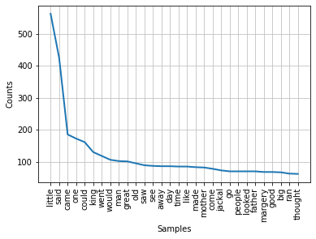

```
for author : edgeworth
<FreqDist with 4513 samples and 20000 outcomes>
[('said', 384), ('one', 140)]
```

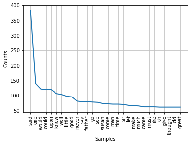

```
for author : melville
<FreqDist with 6903 samples and 20000 outcomes>
[('whale', 221), ('one', 166)]
```

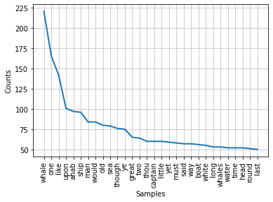

```
for author : chesterton
<FreqDist with 5612 samples and 20000 outcomes>
[('said', 334), ('turnbull', 276)]
```

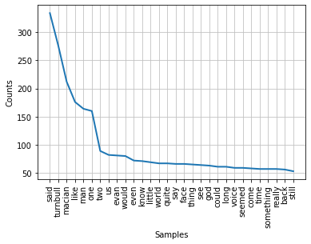

```
for author : milton
<FreqDist with 5775 samples and 20000 outcomes>
[('thy', 194), ('heaven', 187)]
```

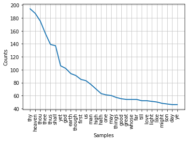

```python
print("showing word frequency in terms of authors for different partitions")
print("This one is for random words which has been picked without replacement")
merged_d = create_dict_with_text_merged(df_with_random_picks)
plot_freq_dist_word_in_terms_of_authors(merged_d)
```

```
This one is for frequency of 2 words which has been picked without replacement for the partitions
for author : bryant
<FreqDist with 313 samples and 400 outcomes>
[('little', 12), ('said', 6)]
```

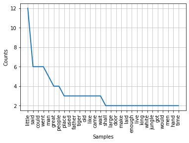

```
for author : edgeworth
<FreqDist with 326 samples and 400 outcomes>
[('said', 8), ('say', 4)]
```

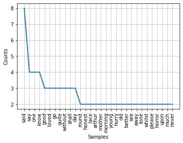

```
for author : melville
<FreqDist with 363 samples and 400 outcomes>
[('ye', 4), ('whale', 4)]
```

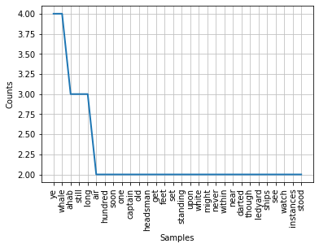

```
for author : chesterton
<FreqDist with 322 samples and 400 outcomes>
[('two', 7), ('said', 6)]
```

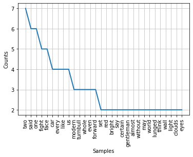

```
for author : milton
<FreqDist with 342 samples and 400 outcomes>
[('us', 4), ('earth', 4)]
```

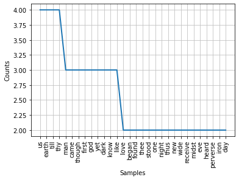

```python
print("This one is for frequency of 2 words which has been picked without replacement for the partitions")
merged_d = create_dict_with_text_merged(df_with_2_gram)
plot_freq_dist_word_in_terms_of_authors(merged_d)
```

```
This one is for 100 continuous words which has been picked without replacement for parititions
for author : bryant
<FreqDist with 2879 samples and 20000 outcomes>
[('little', 538), ('said', 425)]
```

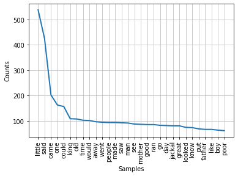

```
for author : edgeworth
<FreqDist with 4199 samples and 20000 outcomes>
[('said', 417), ('one', 142)]
```

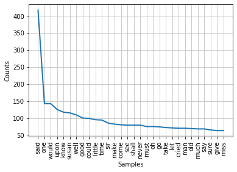

```
for author : melville
<FreqDist with 6421 samples and 20000 outcomes>
[('whale', 232), ('one', 171)]
```

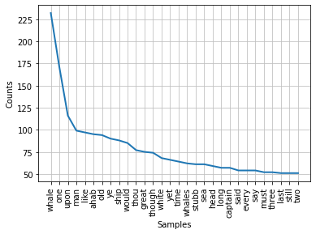

```
for author : chesterton
<FreqDist with 4768 samples and 20000 outcomes>
[('said', 334), ('turnbull', 255)]
```

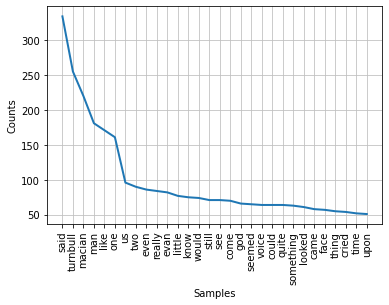

```
for author : milton
<FreqDist with 4947 samples and 20000 outcomes>
[('thou', 220), ('heaven', 197)]
```

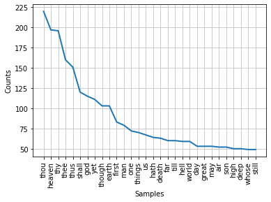

```python
print("This one is for 100 continuous words which has been picked without replacement for parititions")
merged_d = create_dict_with_text_merged(df_with_100_gram)
plot_freq_dist_word_in_terms_of_authors(merged_d)
```

Now we will use TFID for feature engineering, as there is clearly a relationship between the frequency of words and the authors.

```python
new_df_shuffled = df_with_100_gram.sample(frac=1).reset_index(drop=True) # reshuffing the indexes
```

```python
new_df_shuffled.head()
```

|  | authors_name | context |
| --- | --- | --- |
| 0 | chesterton | like one toy grottos children make one place h... |
| 1 | bryant | away horse chased looked shoulder cried run ru... |
| 2 | melville | politely motioned get bed rolling one side muc... |
| 3 | milton | got plenty hung tempting nigh pluck eat fill s... |
| 4 | milton | mastery dissect long tedious havock fabled kni... |

```python
#ngram function
def ngram_extractor(text, n_gram):
    token = [token for token in text.lower().split(" ")]
    ngrams = zip(*[token[i:] for i in range(n_gram)])
    return [" ".join(ngram) for ngram in ngrams]

# Function to generate a dataframe with n_gram and top max_row frequencies
def generate_ngrams(df, n_gram, max_row):
    temp_dict = defaultdict(int)
    for question in df['context']:
        for word in ngram_extractor(question, n_gram):
            temp_dict[word] += 1
    temp_df = pd.DataFrame(sorted(temp_dict.items(), key=lambda x: x[1])[::-1]).head(max_row)
    temp_df.columns = ["word", "wordcount"]
    return temp_df
```

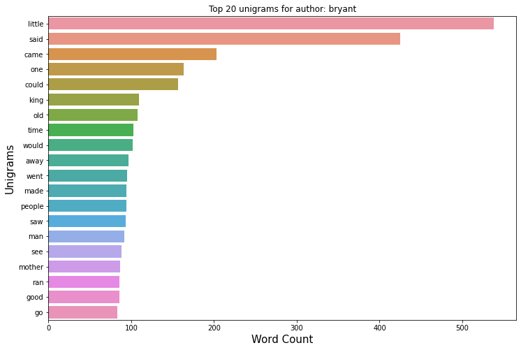

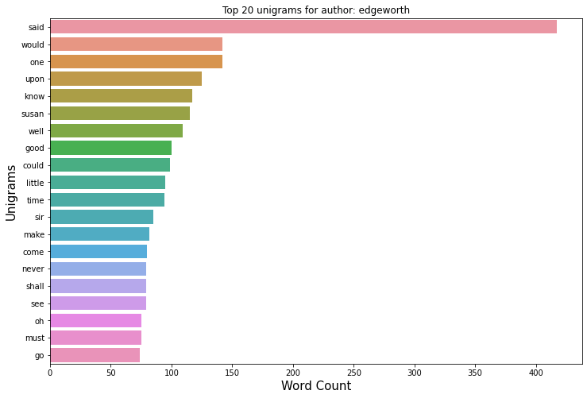

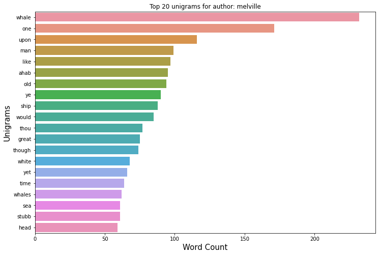

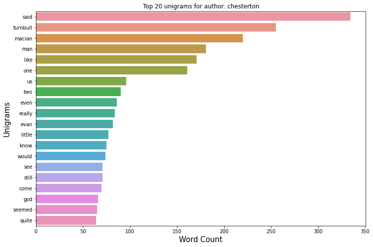

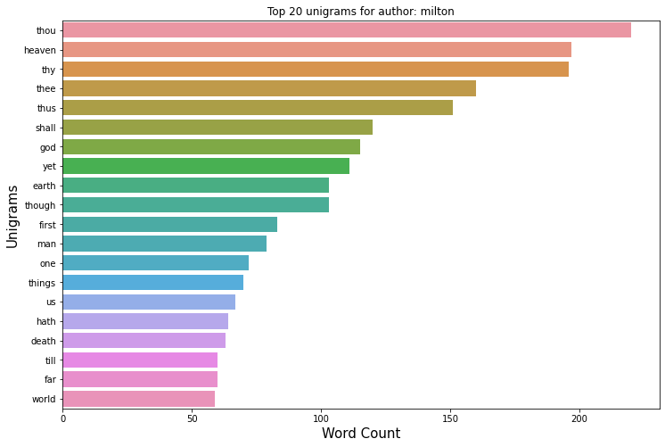

```python
#generate unigram plot for the authors
for author in merged_d.keys():
    temp_df = pd.DataFrame({'context': [merged_d[author]]})
    ans_unigram = generate_ngrams(temp_df, 1, 20)
    #generate barplot for unigram
    plt.figure(figsize=(12,8))
    sns.barplot(ans_unigram["wordcount"],ans_unigram["word"])
    plt.xlabel("Word Count", fontsize=15)
    plt.ylabel("Unigrams", fontsize=15)
    title = "Top 20 unigrams for author: " + author
    plt.title(title)
    plt.show()
```

[figure not shown]

[figure not shown]

[figure not shown]

[figure not shown]

[figure not shown]

```python
#generate bigram plot for the authors
for author in merged_d.keys():
    temp_df = pd.DataFrame({'context': [merged_d[author]]})
    ans_bigram = generate_ngrams(temp_df, 2, 20)
    #generate barplot for unigram
    plt.figure(figsize=(12,8))
    sns.barplot(ans_bigram["wordcount"],ans_bigram["word"])
    plt.xlabel("Word Count", fontsize=15)
    plt.ylabel("Bigrams", fontsize=15)
    title = "Top 20 bigrams for author: " + author
    plt.title(title)
    plt.show()
```

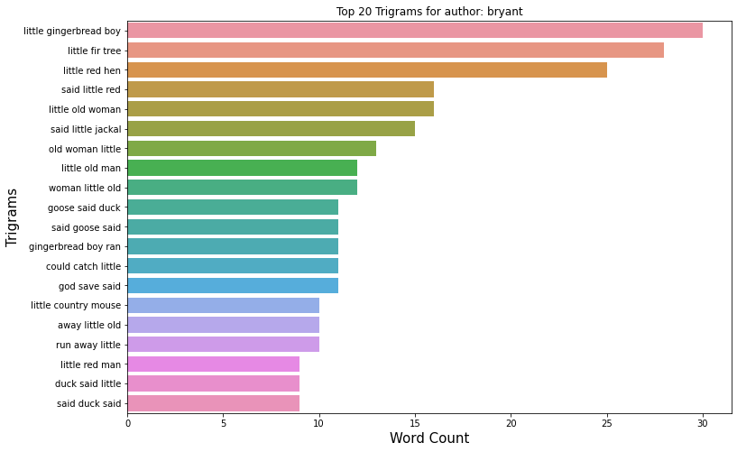

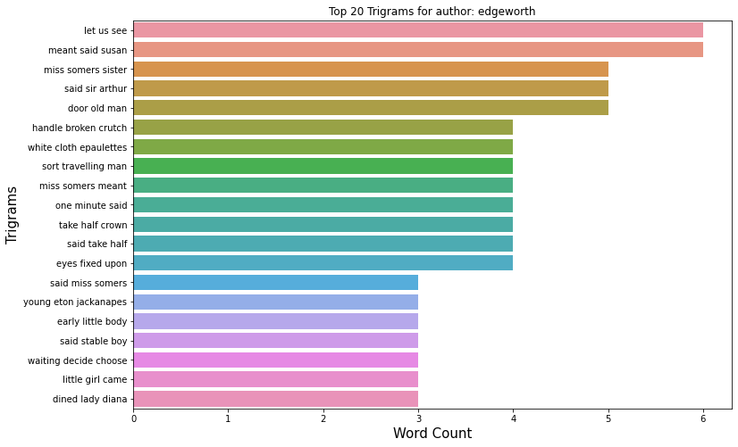

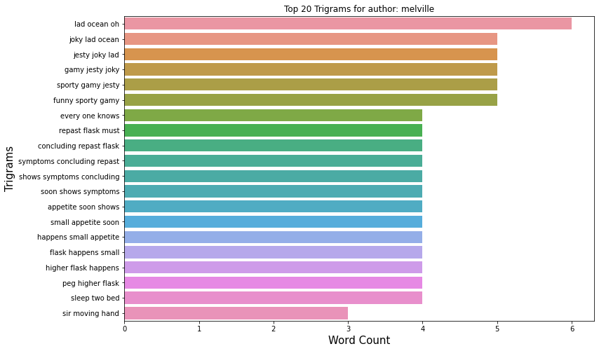

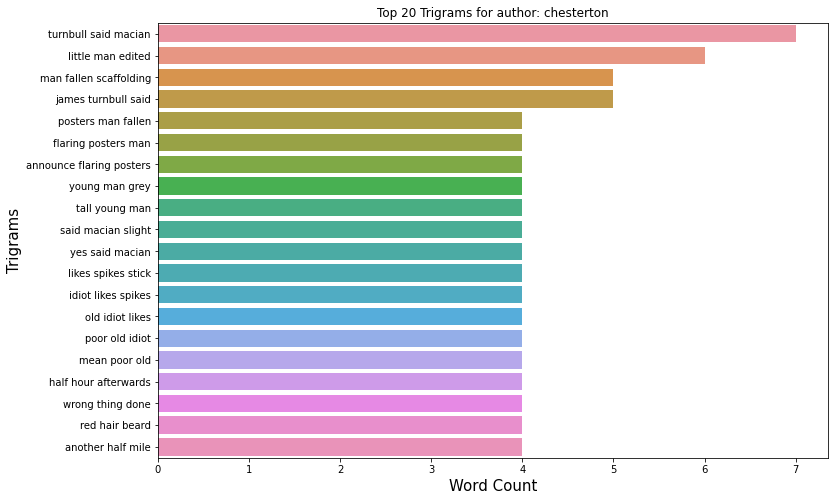

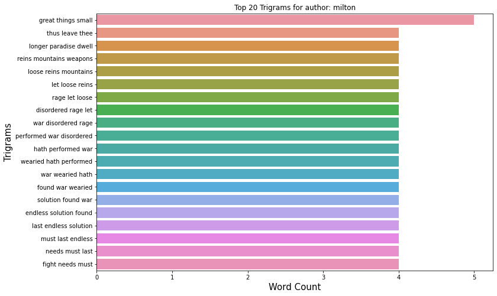

```python
#generate trigram plot for the authors
for author in merged_d.keys():
    temp_df = pd.DataFrame({'context': [merged_d[author]]})
    ans_trigram = generate_ngrams(temp_df, 3, 20)
    #generate barplot for unigram
    plt.figure(figsize=(12,8))
    sns.barplot(ans_trigram["wordcount"],ans_trigram["word"])
    plt.xlabel("Word Count", fontsize=15)
    plt.ylabel("Trigrams", fontsize=15)
    title = "Top 20 Trigrams for author: " + author
    plt.title(title)
    plt.show()
```

for classification we need to encode the authors name into categorical values

```python
from sklearn.preprocessing import LabelEncoder

gle = LabelEncoder()
author_labels = gle.fit_transform(new_df_shuffled['authors_name'])
author_mappings = {index: label for index, label in
                  enumerate(gle.classes_)}
print("represeting authors as: ", author_mappings)
```

```
represeting authors as:  {0: 'bryant', 1: 'chesterton', 2: 'edgeworth', 3: 'melville', 4: 'milton'}
```

```python
new_df_shuffled['authors_name'] = author_labels
new_df_shuffled.head()
```

|  | authors_name | context |
| --- | --- | --- |
| 0 | 2 | soul bring say bursal give joy burs choice ele... |
| 1 | 3 | thought reason absurd frantic weal woe feels u... |
| 2 | 3 | one crested comb starbuck old shake hands man ... |
| 3 | 4 | together sewed gird waist vain covering hide g... |
| 4 | 4 | retires private cell nature rests oft absence ... |

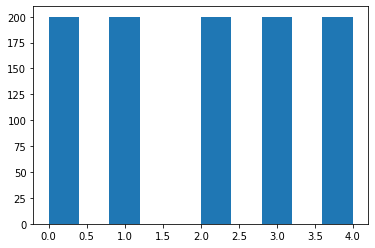

```python
import matplotlib.pyplot as plt

plt.hist(new_df_shuffled['authors_name'])
```

The dataset is balanced containing equal of classification numbers for each of the authors

```python
#SPLITTING THE TRAINING DATASET INTO TRAIN AND TEST
X_train, X_test, y_train, y_test = train_test_split(new_df_shuffled["context"],new_df_shuffled["authors_name"],test_size=0.2,shuffle=True)#Word2Vec
# # Word2Vec runs on tokenized sentences
# X_train_tok= [nltk.word_tokenize(i) for i in X_train]
# X_test_tok= [nltk.word_tokenize(i) for i in X_test]
```

```python
# bag of words
from sklearn.feature_extraction.text import TfidfVectorizer
from sklearn.feature_extraction.text import CountVectorizer#for word embedding
import gensim
from gensim.models import Word2Vec
```

```python
#Tf-Idf
tfidf_vectorizer = TfidfVectorizer(use_idf=True)
X_train_vectors_tfidf = tfidf_vectorizer.fit_transform(X_train)
X_test_vectors_tfidf = tfidf_vectorizer.transform(X_test)
```

```python
# #building Word2Vec model
# class MeanEmbeddingVectorizer(object):
#     def __init__(self, word2vec):
#         self.word2vec = word2vec
#         # if a text is empty we should return a vector of zeros
#         # with the same dimensionality as all the other vectors
#         self.dim = len(next(iter(word2vec.values())))

#     def fit(self, X, y):
#         return self

#     def transform(self, X):
#         return np.array([
#             np.mean([self.word2vec[w] for w in words if w in self.word2vec]
#                     or [np.zeros(self.dim)], axis=0)
#             for words in X
#         ])

# w2v = dict(zip(model.wv.index2word, model.wv.syn0))
# new_df_shuffled['clean_text_tok']=[nltk.word_tokenize(i) for i in new_df_shuffled['context']]
# model = Word2Vec(new_df_shuffled['clean_text_tok'],min_count=1)
# modelw = MeanEmbeddingVectorizer(w2v)

# # converting text to numerical data using Word2Vec
# X_train_vectors_w2v = modelw.transform(X_train_tok)
# X_val_vectors_w2v = modelw.transform(X_test_tok)
```

```python
X, y = tfidf_vectorizer.fit_transform(new_df_shuffled["context"]), new_df_shuffled["authors_name"]
```

```python
#FITTING THE CLASSIFICATION MODEL using Decision Tree(tf-idf)
dt = DecisionTreeClassifier(random_state=42)

dt.fit(X_train_vectors_tfidf, y_train)

#Predict y value for test dataset
y_predict = dt.predict(X_test_vectors_tfidf)
y_prob = dt.predict_proba(X_test_vectors_tfidf)[:,1]

print(classification_report(y_test,y_predict))
print('Confusion Matrix:',confusion_matrix(y_test, y_predict))


# fpr, tpr, thresholds = roc_curve(y_test, y_prob)
# roc_auc = auc(fpr, tpr)
# print('AUC:', roc_auc)
```

[output not shown]

```python
# Create the parameter grid based on the results of random search
params = {
    'max_depth': [5, 10, 20,25],
    'min_samples_leaf': [10, 20, 50, 100,120],
    'criterion': ["gini", "entropy"]
}
```

```python
my_scorer = make_scorer(f1_score, greater_is_better=True, average='micro') #selecting scorer as multiclass label, therefore finding the average
```

```python
grid_search = GridSearchCV(estimator=dt,
                           param_grid=params,
                           cv=10, n_jobs=-1, verbose=1, scoring = my_scorer)
```

```python
best_model=grid_search.fit(X_train_vectors_tfidf, y_train)
```

```
Fitting 10 folds for each of 40 candidates, totalling 400 fits
```

using grid_search and cross validation = 10, with scoring f1 we are ensuring that the model is not overfitted. We can see that the optimum parameters are:

```python
print("best parameters for decision tree", grid_search.best_params_)
print("best score for decision tree", grid_search.best_score_)
```

```
best parameters for decision tree {'criterion': 'gini', 'max_depth': 20, 'min_samples_leaf': 10}
best score for decision tree 0.7250000000000001
```

```python
dt_pred=best_model.predict(X_test_vectors_tfidf)
```

```
Classification Report is:
               precision    recall  f1-score   support

           0       0.80      0.71      0.75        45
           1       0.76      0.81      0.78        36
           2       0.59      0.73      0.66        30
           3       0.80      0.56      0.66        43
           4       0.75      0.89      0.81        46

    accuracy                           0.74       200
   macro avg       0.74      0.74      0.73       200
weighted avg       0.75      0.74      0.74       200


 F1:
 0.74

 Precision score is:
 0.74

 Recall score is:
 0.74

 Accuracy score is:
 0.74

 Confusion Matrix:
```

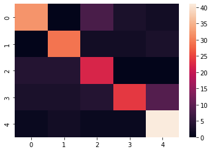

```python
print("Classification Report is:\n",classification_report(y_test,dt_pred))
print("\n F1:\n",f1_score(y_test,dt_pred, pos_label='positive', average='micro'))
print("\n Precision score is:\n",precision_score(y_test,dt_pred, pos_label='positive', average='micro'))
print("\n Recall score is:\n",recall_score(y_test,dt_pred, pos_label='positive', average='micro'))
print("\n Accuracy score is:\n", accuracy_score(y_test,dt_pred))
print("\n Confusion Matrix:\n")
sns.heatmap(confusion_matrix(y_test,dt_pred))
```

```python
svm = SVC(probability=True)
svm.fit(X_train_vectors_tfidf, y_train)

#Predict y value for test dataset
y_predict = svm.predict(X_test_vectors_tfidf)
y_prob = svm.predict_proba(X_test_vectors_tfidf)[:,1]

print(classification_report(y_test,y_predict))
print('Confusion Matrix:',confusion_matrix(y_test, y_predict))
```

```
              precision    recall  f1-score   support

           0       1.00      1.00      1.00        45
           1       1.00      1.00      1.00        36
           2       1.00      0.97      0.98        30
           3       0.98      0.95      0.96        43
           4       0.96      1.00      0.98        46

    accuracy                           0.98       200
   macro avg       0.99      0.98      0.99       200
weighted avg       0.99      0.98      0.98       200

Confusion Matrix: [[45  0  0  0  0]
 [ 0 36  0  0  0]
 [ 0  0 29  1  0]
 [ 0  0  0 41  2]
 [ 0  0  0  0 46]]
```

Despite, SVM showing promising results, we will use Grid Search CV, with k = 10, and find the best parameters for the SVM. This is reduce bias and variability, also not overfitting.

```python
kernel = ['poly', 'rbf', 'sigmoid']
C = [50, 10, 1.0, 0.1, 0.01]
gamma = ['scale']
model = SVC()
```

```python
# define grid search
grid = dict(kernel=kernel,C=C,gamma=gamma)
# cv = RepeatedStratifiedKFold(n_splits=10, n_repeats=3, random_state=1)
grid_search = GridSearchCV(estimator=model, param_grid=grid, n_jobs=-1, cv=10, scoring= my_scorer,error_score=0)
```

```python
grid_result = grid_search.fit(X_train_vectors_tfidf, y_train)
```

```python
print("best parameters for svm", grid_search.best_params_)
print("best score for svm", grid_search.best_score_)
```

```
best parameters for svm {'C': 50, 'gamma': 'scale', 'kernel': 'sigmoid'}
best score for svm 0.99375
```

```python
svm_pred=grid_result.predict(X_test_vectors_tfidf)
```

```
Classification Report is:
               precision    recall  f1-score   support

           0       1.00      1.00      1.00        45
           1       1.00      1.00      1.00        36
           2       1.00      1.00      1.00        30
           3       1.00      0.95      0.98        43
           4       0.96      1.00      0.98        46

    accuracy                           0.99       200
   macro avg       0.99      0.99      0.99       200
weighted avg       0.99      0.99      0.99       200


 F1:
 0.99

 Precision score is:
 0.99

 Recall score is:
 0.99

 Confusion Matrix:
```

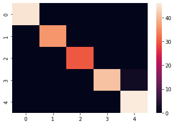

```python
print("Classification Report is:\n",classification_report(y_test,svm_pred))
print("\n F1:\n",f1_score(y_test,svm_pred, pos_label='positive', average='micro'))
print("\n Precision score is:\n",precision_score(y_test,svm_pred, pos_label='positive', average='micro'))
print("\n Recall score is:\n",recall_score(y_test,svm_pred, pos_label='positive', average='micro'))
print("\n Confusion Matrix:\n")
sns.heatmap(confusion_matrix(y_test,svm_pred))
```

```python
knn = KNeighborsClassifier()
knn.fit(X_train_vectors_tfidf, y_train)

#Predict y value for test dataset
y_predict = knn.predict(X_test_vectors_tfidf)
y_prob = knn.predict_proba(X_test_vectors_tfidf)[:,1]

print(classification_report(y_test,y_predict))
print('Confusion Matrix:',confusion_matrix(y_test, y_predict))
```

[output not shown]

```python
k_range = list(range(1, 31))
param_grid = dict(n_neighbors=k_range)
model = KNeighborsClassifier()

# defining parameter range
grid = GridSearchCV(model, param_grid, cv=10, scoring=my_scorer)

# fitting the model for grid search
grid_search=grid.fit(X_train_vectors_tfidf, y_train)
```

```python
print("best parameters for knn", grid_search.best_params_)
print("best score for knn", grid_search.best_score_)
```

```
best parameters for knn {'n_neighbors': 21}
best score for knn 0.9662499999999999
```

```python
knn_pred=grid_result.predict(X_test_vectors_tfidf)
```

```
Classification Report is:
               precision    recall  f1-score   support

           0       1.00      1.00      1.00        45
           1       1.00      1.00      1.00        36
           2       1.00      1.00      1.00        30
           3       1.00      0.95      0.98        43
           4       0.96      1.00      0.98        46

    accuracy                           0.99       200
   macro avg       0.99      0.99      0.99       200
weighted avg       0.99      0.99      0.99       200


 F1:
 0.99

 Precision score is:
 0.99

 Recall score is:
 0.99

 Confusion Matrix:
```

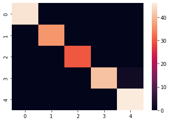

```python
print("Classification Report is:\n",classification_report(y_test,knn_pred))
print("\n F1:\n",f1_score(y_test,knn_pred, pos_label='positive', average='micro'))
print("\n Precision score is:\n",precision_score(y_test,knn_pred, pos_label='positive', average='micro'))
print("\n Recall score is:\n",recall_score(y_test,knn_pred, pos_label='positive', average='micro'))
print("\n Confusion Matrix:\n")
sns.heatmap(confusion_matrix(y_test,knn_pred))
```

Now we will continue with KNN and SVM, as they are the best model. We will drop the dataset and use the same dataset and feature engineering to see the results.

```python
df_with_50_gram = parition_ngrams(df_raw_corpus_test, t_size = 100, partition_n = 50, n = 50)
```

```python
new_df_shuffled_2 = df_with_50_gram.sample(frac=1).reset_index(drop=True)
```

```python
new_df_shuffled_2.head()
```

|  | authors_name | context |
| --- | --- | --- |
| 0 | milton | th adventure voice forbidding rose rising soun... |
| 1 | milton | temptation transgress repel saying arose adam ... |
| 2 | bryant | shouted beat beast went slowly backward clock ... |
| 3 | chesterton | feel coming dive deep enough abyss feel rising... |
| 4 | chesterton | better policemen fat make policemen fat much t... |

```
This one is for 50 continuous words of size 100 which has been picked without replacement for parititions of 50
for author : 4
<FreqDist with 1529 samples and 2500 outcomes>
[('thou', 33), ('heaven', 24)]
```

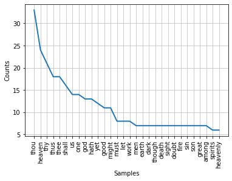

```
for author : 0
<FreqDist with 982 samples and 2500 outcomes>
[('said', 71), ('little', 65)]
```

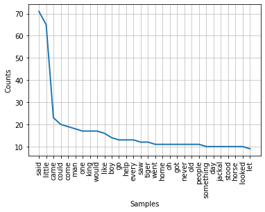

```
for author : 1
<FreqDist with 1364 samples and 2500 outcomes>
[('said', 39), ('turnbull', 36)]
```

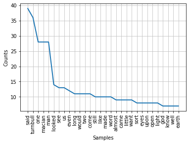

```
for author : 3
<FreqDist with 1551 samples and 2500 outcomes>
[('whale', 23), ('ahab', 21)]
```

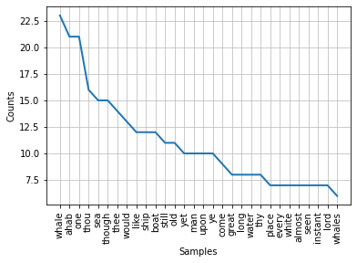

```
for author : 2
<FreqDist with 1252 samples and 2500 outcomes>
[('said', 43), ('could', 27)]
```

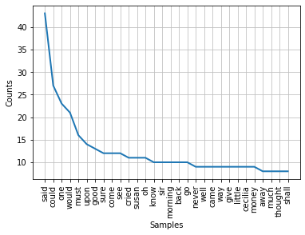

```python
print("This one is for 50 continuous words of size 100 which has been picked without replacement for parititions of 50")
merged_d = create_dict_with_text_merged(new_df_shuffled_2)
plot_freq_dist_word_in_terms_of_authors(merged_d)
```

```python
from sklearn.preprocessing import LabelEncoder

gle = LabelEncoder()
author_labels = gle.fit_transform(new_df_shuffled_2['authors_name'])
author_mappings = {index: label for index, label in
                  enumerate(gle.classes_)}
print("represeting authors as: ", author_mappings)
```

```
represeting authors as:  {0: 'bryant', 1: 'chesterton', 2: 'edgeworth', 3: 'melville', 4: 'milton'}
```

```python
new_df_shuffled_2['authors_name'] = author_labels
new_df_shuffled_2.head()
```

|  | authors_name | context |
| --- | --- | --- |
| 0 | 4 | th adventure voice forbidding rose rising soun... |
| 1 | 4 | temptation transgress repel saying arose adam ... |
| 2 | 0 | shouted beat beast went slowly backward clock ... |
| 3 | 1 | feel coming dive deep enough abyss feel rising... |
| 4 | 1 | better policemen fat make policemen fat much t... |

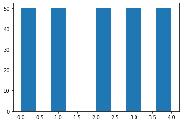

```python
plt.hist(new_df_shuffled_2['authors_name'])
```

```python
#SPLITTING THE TRAINING DATASET INTO TRAIN AND TEST
X_train, X_test, y_train, y_test = train_test_split(new_df_shuffled_2["context"],new_df_shuffled_2["authors_name"],test_size=0.2,shuffle=True)#Word2Vec
```

```python
#Tf-Idf
tfidf_vectorizer = TfidfVectorizer(use_idf=True)
X_train_vectors_tfidf = tfidf_vectorizer.fit_transform(X_train)
X_test_vectors_tfidf = tfidf_vectorizer.transform(X_test)
```

```python
svm = SVC(C = 50, gamma = 'scale', kernel = 'sigmoid')
```

```
              precision    recall  f1-score   support

           0       1.00      0.90      0.95        10
           1       1.00      0.91      0.95        11
           2       1.00      1.00      1.00         7
           3       0.86      0.86      0.86        14
           4       0.80      1.00      0.89         8

    accuracy                           0.92        50
   macro avg       0.93      0.93      0.93        50
weighted avg       0.93      0.92      0.92        50

Classification Report is:
               precision    recall  f1-score   support

           0       1.00      0.90      0.95        10
           1       1.00      0.91      0.95        11
           2       1.00      1.00      1.00         7
           3       0.86      0.86      0.86        14
           4       0.80      1.00      0.89         8

    accuracy                           0.92        50
   macro avg       0.93      0.93      0.93        50
weighted avg       0.93      0.92      0.92        50


 F1:
 0.92

 Precision score is:
 0.92

 Recall score is:
 0.92

 Confusion Matrix:
```

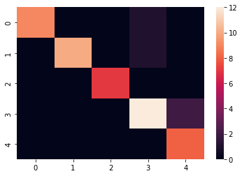

```python
svm.fit(X_train_vectors_tfidf, y_train)

#Predict y value for test dataset
y_predict = svm.predict(X_test_vectors_tfidf)
# y_prob = svm.predict_proba(X_test_vectors_tfidf)[:,1]

print(classification_report(y_test,y_predict))
print("Classification Report is:\n",classification_report(y_test,y_predict))
print("\n F1:\n",f1_score(y_test,y_predict, pos_label='positive', average='micro'))
print("\n Precision score is:\n",precision_score(y_test,y_predict, pos_label='positive', average='micro'))
print("\n Recall score is:\n",recall_score(y_test,y_predict, pos_label='positive', average='micro'))
print("\n Confusion Matrix:\n")
sns.heatmap(confusion_matrix(y_test,y_predict))
```

```
Classification Report is:
               precision    recall  f1-score   support

           0       0.75      0.90      0.82        10
           1       0.70      0.64      0.67        11
           2       1.00      0.57      0.73         7
           3       0.50      0.64      0.56        14
           4       0.67      0.50      0.57         8

    accuracy                           0.66        50
   macro avg       0.72      0.65      0.67        50
weighted avg       0.69      0.66      0.66        50


 F1:
 0.66

 Precision score is:
 0.66

 Recall score is:
 0.66

 Confusion Matrix:
```

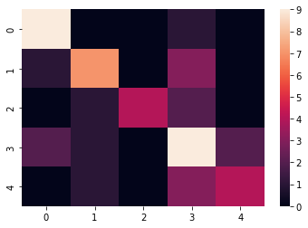

```python
knn = KNeighborsClassifier(n_neighbors=1)
knn.fit(X_train_vectors_tfidf, y_train)

#Predict y value for test dataset
y_predict = knn.predict(X_test_vectors_tfidf)
# y_prob = knn.predict_proba(X_test_vectors_tfidf)[:,1]

print("Classification Report is:\n",classification_report(y_test,y_predict))
print("\n F1:\n",f1_score(y_test,y_predict, pos_label='positive', average='micro'))
print("\n Precision score is:\n",precision_score(y_test,y_predict, pos_label='positive', average='micro'))
print("\n Recall score is:\n",recall_score(y_test,y_predict, pos_label='positive', average='micro'))
print("\n Confusion Matrix:\n")
sns.heatmap(confusion_matrix(y_test,y_predict))
```

From the results we can see there was almost a 30 percent drop in the percentage when we changed the dataset for KNN, however, SVM ran straight and therefore SVM is the champion model with accuracy 92 percent and F1 score 92 percent.